# Chapter 5 Nonlinear models

# Ensemble models

Ensemble models are a machine learning technique by combining the predictions of multiple individual models to have a more accurate/robust prediction. By combining the diverse opinions of multiple models, the resulting prediction is often better than that of any single model. They are widely used in various machine learning tasks and have proven to be effective in improving predictive performance and reducing overfitting.

In the context of neural networks, ensemble approaches such as avNNet (from the caret package) extend the basic nnet model by training several networks with random initial weights and averaging their predictions. This helps to stabilize performance, reduce overfitting, and enhance predictive accuracy, especially on complex datasets. Ensemble neural networks are widely used in both regression and classification tasks where consistency and reliability of prediction are critical.

```r
library(caret)
library(nnet)
```

```r
#train function

set.seed(295)

#the cross validation setting  10 fold cross validation
ctrl = trainControl(method = "cv", number = 10)

#When you train a neural network (nnet) using Caret
#two hyper-parameters: size (the number of nodes in the hidden layer) and decay.

#Size is the number of units in hidden layer (nnet fit a single hidden layer neural network)
#and decay is the regularization parameter to avoid over-fitting
# 42 options
nnet.Grid = expand.grid(decay = c(0, 0.01, 0.025, 0.05, 0.075, .1, 0.2), size = 3:8, bag = FALSE)
#or

#nnet.Grid <-  expand.grid(size = 1:8,decay = seq(from = 0.1, to = 0.5, by = 0.1), bag=FALSE)
#Averaged Neural Networks
#A type of neural network ensemble method that combines multiple neural networks to make predictions.
#"ensemble" used to improve the generalization and robustness of predictions(
# to reduce overfitting and improve prediction accuracy)
avnet.fit = train(medv ~ ., data = train.dat,
                  method = "avNNet",
                  tuneGrid = nnet.Grid,
                  trControl = ctrl,
                  preProc = c("center", "scale"),
                  linout = TRUE,
                  trace = FALSE,
                  maxit = 100,
                  allowParallel = FALSE)


#yhat0 = predict(nnet.fit, test.dat)

#Transform back to the orignal scale
#yhat0 = yhat0*range.y + miny
#plot(test.dat$medv1, yhat0,  xlab="observed value", ylab ="predicted value")
```

```r
#summary(avnet.fit)
#avnet.fit

#Make prediction on the testing data
yhat.avnet = predict(avnet.fit, test.dat)

#Transform back to the orignal scale
yhat0 = yhat.avnet*range.y + miny

#Tranform the observed data back to the original scale
test.dat$medv1 = test.dat$medv*range.y + miny
```

```r
#RMSE
#sqrt(mean( (yhat0 - test.dat$medv1)^2 ))

#MAE on the testing data of the fitted model
caret::MAE(test.dat$medv1, yhat0)
#RMSE on the testing data of the fitted model
caret::RMSE(test.dat$medv1, yhat0)

#R^2 on the testing data of the fitted model
caret::R2(test.dat$medv1, yhat0)

#
```

1.98835148509011

2.96766039382599

0.899216498651104

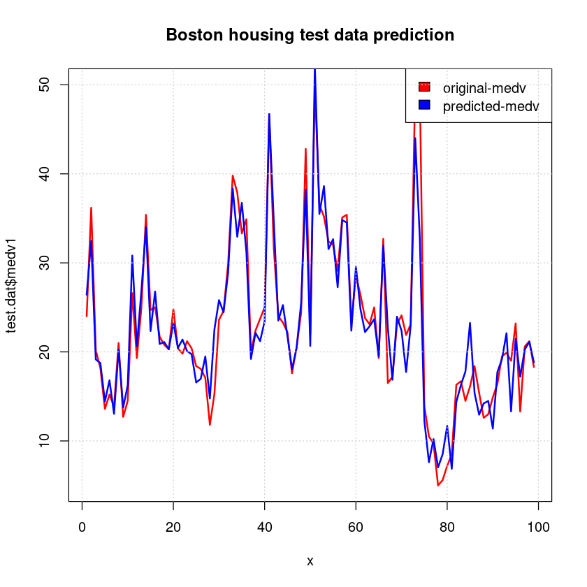

```r
#Line plots to see the performance
#Predicted value vs observed values
x = 1:length(yhat0)
plot(x, test.dat$medv1, col = "red", type = "l", lwd=2,
     main = "Boston housing test data prediction")
lines(x, yhat0, col = "blue", lwd=2)
legend("topright",  legend = c("original-medv", "predicted-medv"),
       fill = c("red", "blue"), col = 2:3,  adj = c(0, 0.6))
grid()
```

### Neural Network Regression Model using TensorFlow/Keras in R

The neural network consists of:

Input layer: 13 input nodes (matching the number of predictors)

Hidden Layer 1: 6 neurons, activation = ReLU

Hidden Layer 2: 4 neurons, activation = ReLU

Output layer: 1 neuron, activation = Linear (for continuous prediction)

Loss function: Mean Squared Error (MSE) — measures model error in squared units

Metric: Root Mean Squared Error (RMSE) — interpretable in original scale

```r
library(keras)
use_session_with_seed(53289)

# Extract predictors (first 13 variables) and response (14th variable)
train.x = as.matrix(train.dat[, -14])
train.y = as.matrix(train.dat[, 14])

# Assume test.dat is prepared in the same structure
test.x = as.matrix(test.dat[, -14])
test.y = as.matrix(test.dat[, 14])

# Get the number of predictors (features)
n_features = ncol(train.x)

# Build a neural network model with two hidden layers: 6 and 4 neurons
fit.1 = keras_model_sequential() %>%
  layer_dense(units = 6, activation = "relu", input_shape = n_features) %>%
  layer_dense(units = 4, activation = "relu") %>%
  layer_dense(units = 1, activation = "linear")

# Compile the model: regression with MSE loss and RMSE metric
fit.1 %>% compile(
  optimizer = optimizer_adam(learning_rate = 0.001),
  loss = "mse",
  metrics = list(metric_root_mean_squared_error())
)

# Train the model on the training data
history = fit.1 %>% fit(
  x = train.x, y = train.y,
  epochs = 200,
  batch_size = 32,
  validation_split = 0.2,
  verbose = 0
)

# Predict on the test dataset
y_pred = as.numeric(fit.1 %>% predict(test.x))
```

[output not shown]

[output not shown]

[output not shown]

Excerise: The "concrete" dataset (from the AppliedPredictiveModeling package) contains measurements of ingredient proportions used to make concrete and the resulting CompressiveStrength.

Reproducibility: set seed = 53289.

Data split: create a training/test split (e.g., 80/20). Scaling: apply min_max scaling before build the predecitive model.

a. Use the neuralnet package to build a neural network model that predicts CompressiveStrength using all other features in the Concrete dataset.

b. Use the nnet package and Ensemble models to build a neural network model to predict CompressiveStrength using all other features.

c. Use the average nnet (ensemble model) to build a predictive model that predicts CompressiveStrength using all other features on a training dataset.

d. Evaluate each model on a test dataset. Compute and report performance metrics such as Root Mean Squared Error (RMSE) and produce a scatter plot of true vs. predicted values to visually assess model accuracy. Please use seed = 53289.

```r
library(AppliedPredictiveModeling)

data(concrete)

head(concrete)

#Please use 'neuralnet' to build a neural network to predict 'CompressiveStrength'
```

A data.frame: 6 × 9

|  | Cement <dbl> | BlastFurnaceSlag <dbl> | FlyAsh <dbl> | Water <dbl> | Superplasticizer <dbl> | CoarseAggregate <dbl> | FineAggregate <dbl> | Age <int> | CompressiveStrength <dbl> |
| --- | --- | --- | --- | --- | --- | --- | --- | --- | --- |
| 1 | 540.0 | 0.0 | 0 | 162 | 2.5 | 1040.0 | 676.0 | 28 | 79.99 |
| 2 | 540.0 | 0.0 | 0 | 162 | 2.5 | 1055.0 | 676.0 | 28 | 61.89 |
| 3 | 332.5 | 142.5 | 0 | 228 | 0.0 | 932.0 | 594.0 | 270 | 40.27 |
| 4 | 332.5 | 142.5 | 0 | 228 | 0.0 | 932.0 | 594.0 | 365 | 41.05 |
| 5 | 198.6 | 132.4 | 0 | 192 | 0.0 | 978.4 | 825.5 | 360 | 44.30 |
| 6 | 266.0 | 114.0 | 0 | 228 | 0.0 | 932.0 | 670.0 | 90 | 47.03 |

```r
dat = concrete

scale.fun = function(x){
  (x - min(x)) / (max(x) - min(x))
}

miny = min(dat$CompressiveStrength)
range.y =  max(dat$CompressiveStrength) - miny

#Transformed data
dat.2 = dat %>%  mutate_all(scale.fun)

#Split the data into training set and testing set

set.seed(53289)

index = createDataPartition(dat$CompressiveStrength, p = 0.8, list = FALSE)
train.dat = dat.2[index,]
test.dat =   dat.2[-index,]
```

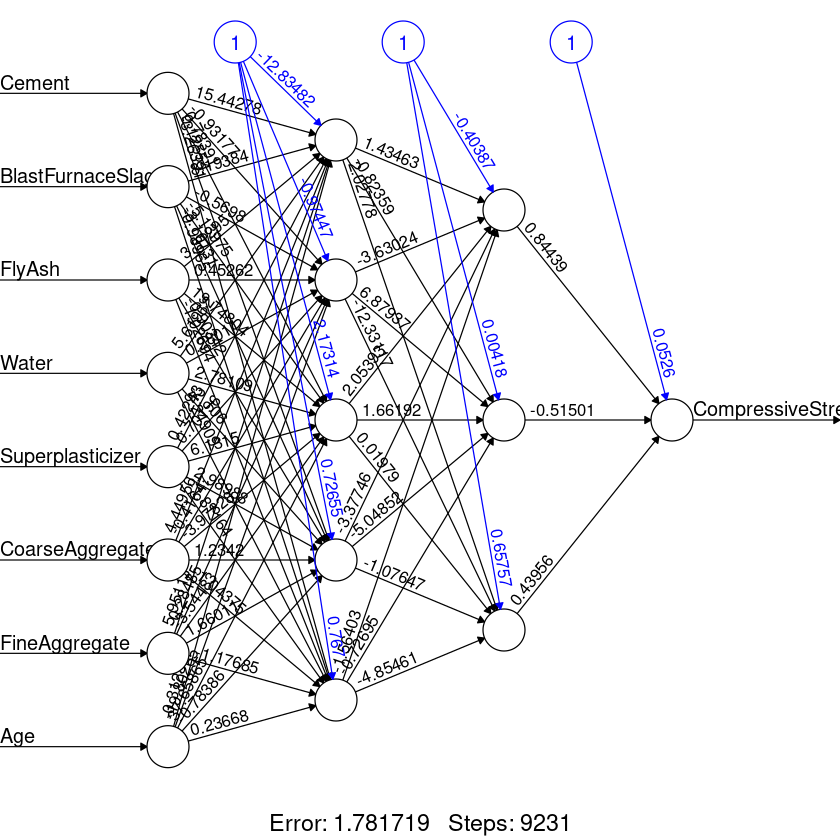

6.41401416538716

A matrix: 1 × 1 of type dbl

| 0.8611744 |
| --- |

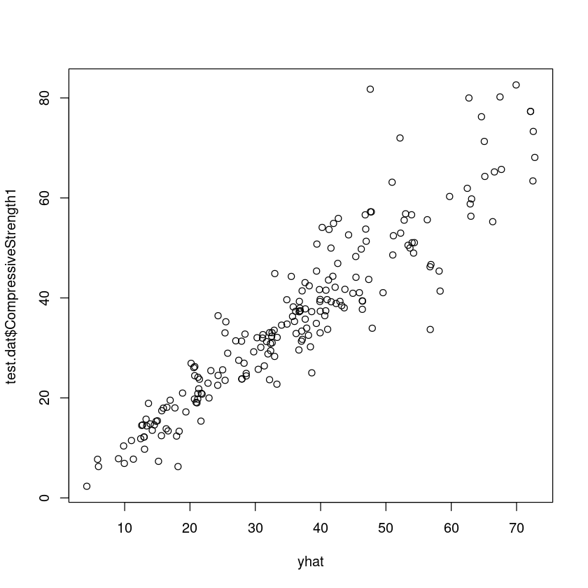

```r
#Build a neural network on the training data
#hidden = c(5, 3) : two hidder layers,  5 neurons in the first hidden layer and 3 neurons in the second hidder layer
nn.fit = neuralnet(CompressiveStrength ~ ., data = train.dat, hidden = c(5, 3), linear.output = 1)

plot(nn.fit, rep = "best")

# Make prediction on the test data

#To make prediction using the testing data
yhat.0 = predict(nn.fit, test.dat)


#Transform the results back to the orginal scale
yhat = yhat.0*range.y + miny
test.dat$CompressiveStrength1 = test.dat$CompressiveStrength*range.y + miny

#MSE on the testing data
plot(yhat, test.dat$CompressiveStrength1)

#RMSE
sqrt(mean( (yhat - test.dat$CompressiveStrength1)^2 ))

#R sqaured
(cor(yhat, test.dat$CompressiveStrength1 ))^2
```

```r
library(caret)
library(nnet)
```

```r
#train function

set.seed(53289)

#the cross validation setting  5 fold cross validation
ctrl = trainControl(method = "cv", number = 5)

# 30 options
nnet.Grid = expand.grid(decay = c(0, 0.01, 0.025, 0.05, .1), size = 3:8, bag = FALSE)

avnet.fit = train(CompressiveStrength ~ ., data = train.dat,
                  method = "avNNet",
                  tuneGrid = nnet.Grid,
                  trControl = ctrl,
                  preProc = c("center", "scale"),
                  linout = TRUE,
                  trace = FALSE,
                  maxit = 100,
                  allowParallel = FALSE)


#yhat0 = predict(nnet.fit, test.dat)
#summary(avnet.fit)
#avnet.fit

#Make prediction on the testing data
yhat.avnet = predict(avnet.fit, test.dat)

#Transform back to the orignal scale
yhat0 = yhat.avnet*range.y + miny

#Tranform the observed data back to the original scale
test.dat$CompressiveStrength1 = test.dat$CompressiveStrength*range.y + miny


#RMSE
#sqrt(mean( (yhat0 - test.dat$medv1)^2 ))

#MAE on the testing data of the fitted model
caret::MAE(test.dat$CompressiveStrength1, yhat0)
#RMSE on the testing data of the fitted model
caret::RMSE(test.dat$CompressiveStrength1, yhat0)

#R^2 on the testing data of the fitted model
caret::R2(test.dat$CompressiveStrength1, yhat0)

#
```

3.87470584264107

5.38848259823254

0.902823926814162

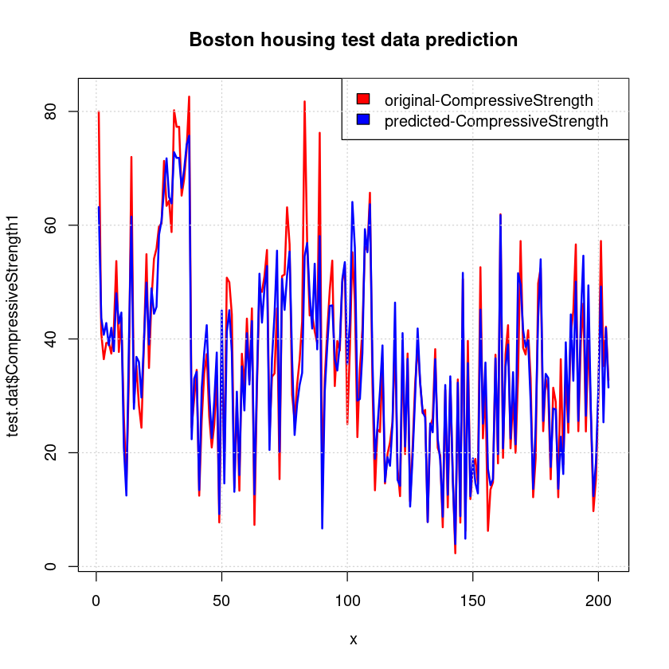

```r
#Line plots to see the performance
#Predicted value vs observed values
x = 1:length(yhat0)
plot(x, test.dat$CompressiveStrength1, col = "red", type = "l", lwd=2,
     main = "Boston housing test data prediction")
lines(x, yhat0, col = "blue", lwd=2)
legend("topright",  legend = c("original-CompressiveStrength", "predicted-CompressiveStrength"),
       fill = c("red", "blue"), col = 2:3,  adj = c(0, 0.6))
grid()
```